# will_ai_replace_us slides

**WILL AI REPLACE U ?**

AI as we know it is every where now and everyone is affected by it in one way or the other. Before 2020, your skill and expertise will tell how well you will perform at your job. Nowadays as the case may be, it's usually how well you can leverage AI in your said Job that'll determine how well you can perform.

Will AI take our Jobs or will someone using AI replace you?

Don't worry you'll find out in my analysis. Stay put, Read the code, Go through the Analysis, Enjoy xD

*run code blocks one after the other, in order they appear to avoid undefined errors.....*

```python
#importing libraries
import pandas as pd
import numpy as np
import matplotlib.pyplot as plt
```

```python
#grab csv dataset and put in a dataframe
df = pd.read_csv(f"C:\\Users\\user\\Documents\\Data Analysis\\will ai replace you\\AI_IN_WORKFORCE_DATASET.csv")
```

```python
#select job titles under Data & IT and store in new dataframe
tech_employees = df[df["Domain"] == "Data & IT"]
```

The AI Impact Ratio is the percentage impact of ai per workload for any given Domain in the workforce.

Let me show you what I'm talking about, taking the Data & IT Domain as a good example

The code snippet below calculates the AI Impact Ratio for the Data & IT Domain. A plot will be done using a sample of the top 3 and least 2 go get the estimate range of the dataset

```python
#calculating ai impact ratio for all columns and saving in a list

ai_workload_ratio =[]
ai_impact = []
ai_impact_ratio = []

for ratio in tech_employees["AI_Workload_Ratio"] :
    ai_workload_ratio.append(ratio)
for impact in tech_employees["AI Impact"] :
    ai_impact.append(int(impact.replace('%',''))/100)

k = len(ai_workload_ratio)
v = 0
#calculating the impact of ai per workload
while v <= k - 1 :
    impact_ratio = ai_workload_ratio[v] * ai_impact[v]
    ai_impact_ratio.append(impact_ratio)
    v += 1
#creating a new column and populating it with the ai_impact_ratio list
tech_employees["ai_impact_ratio"] = ai_impact_ratio
tech_employees
```

|  | Job titiles | AI Impact | Tasks | AI models | AI_Workload_Ratio | Domain | ai_impact_ratio |
| --- | --- | --- | --- | --- | --- | --- | --- |
| 1 | Data Collector | 95% | 299 | 2148 | 0.139199 | Data & IT | 0.132239 |
| 11 | Data Clerk | 90% | 317 | 2258 | 0.140390 | Data & IT | 0.126351 |
| 21 | Delivery Driver | 88% | 20 | 309 | 0.064725 | Data & IT | 0.056958 |
| 31 | Transcriber | 85% | 205 | 1359 | 0.150846 | Data & IT | 0.128219 |
| 41 | Clerk Typist | 83% | 263 | 1986 | 0.132427 | Data & IT | 0.109914 |
| ... | ... | ... | ... | ... | ... | ... | ... |
| 4661 | Salon Assistant | 5% | 298 | 1561 | 0.190903 | Data & IT | 0.009545 |
| 4671 | Payroll | 5% | 667 | 2667 | 0.250094 | Data & IT | 0.012505 |
| 4681 | Admissions Coordinator | 5% | 1188 | 4603 | 0.258093 | Data & IT | 0.012905 |
| 4691 | Fire Watch | 5% | 261 | 1008 | 0.258929 | Data & IT | 0.012946 |
| 4701 | Singer | 5% | 686 | 2798 | 0.245175 | Data & IT | 0.012259 |

471 rows × 7 columns

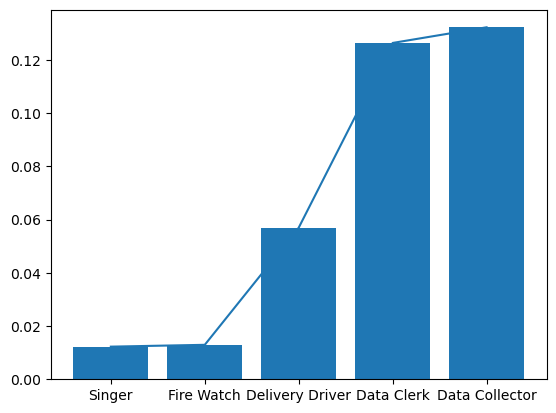

```python
#selects the top 3 and last 2 as a sample to get an idea of how ai can effect(very high or very low) unrelated Domains
tech_employees_sample = pd.concat([tech_employees.head(3), tech_employees.tail(2)]).drop_duplicates().reset_index(drop=True)
tech_employees_sample = tech_employees_sample.sort_values(by = 'ai_impact_ratio')
bar_plot = plt.bar(tech_employees_sample['Job titiles'], tech_employees_sample['ai_impact_ratio'])
line_plot = plt.plot(tech_employees_sample['Job titiles'], tech_employees_sample['ai_impact_ratio'])
```

From the above plots, I can say that AI has a higher effect on a Data Collector and Data Clerk (highest in the plot) than it has on a Singer and A fir Watch Man. Now you see what I'm talking about? Although AI has impact on Jobs of unrelated Domains, there seems to be a close margin when the Domain are related, In this case the Data Clerk and Data Collector. Let's dive deeper

This is just a sample analysis to get going, just so I can get a hint about the dataset

It's high time I open a soundcloud account and start singing for fear of been replaced by AI, as we're impacted the most (I mean we that work in tech generally)

Either way you can't deny the fact that AI will change the way you approach the work force and your career in general y'know. When push comes to shove it'll either be you replacing somebody in the workforce or getting replaced by someone else, most especially if you're working in tech....

Accept AI, apply it in your field, adopt, grow, level up and drop your skill issues(I've started dropping mine \*(* *-* *)*/ ). Wish you all the best.

Message me on X if you have suggestions or just to yap about what you thinkk aboutthe analysis. It'll do alot for me, Thank you.

```python
#algorithm to count the number or rows and columns in a dataframe in O(n) time without hashmap
def find_col_row(dataframe) :
    col_count = 0
    row_count = 0
    for col in dataframe :
        col_count += 1
    row_count = len(tech_employees)
    print(f'{row_count} rows x {col_count} columns')
find_col_row(df)
```

```
471 rows x 6 columns
```

```python
#algorithm to count the number or rows and columns in a dataframe in O(n) time using hashmaps
def find_col_row(dataframe):
    col_count = 0
    row_count = 0
    row_col = {} #hashmap, hashtable or dictionary
    for col in dataframe :
        row_col[col] = tech_employees[col]

    for col in row_col :
        col_count += 1
        row_count = len(row_col[col])
    print(f'{row_count} rows x {col_count} columns')
find_col_row(df)
```

```
471 rows x 6 columns
```

Analysis By @EbubeAkukwe on x[dot]com